# Natural Language Processing Project

# NLP: Sentiment Analysis and Topic Modeling

### 1. Description of the dataset and what it represents

```python
# Importing necessary libraries
import pandas as pd
import re
import nltk
from nltk.corpus import stopwords
from sklearn.feature_extraction.text import CountVectorizer
import unicodedata
import numpy as np

nltk.download('punkt')
nltk.download('stopwords')

# use spacy in datalore
import spacy
#%%
import subprocess
#%%
print(subprocess.getoutput("python -m spacy download en_core_web_sm"))
from spacy.lang.en import STOP_WORDS as spacy_stopwords

# Load the SpaCy model
nlp = spacy.load("en_core_web_sm")

# Add custom stop words
custom_stopwords = {"it's", "i'm", "you're", "we're", "they're", "he's", "she's"}
spacy_stopwords = spacy_stopwords.union(custom_stopwords)

from collections import Counter
from nltk.lm.preprocessing import flatten
from nltk.util import ngrams

# function to convert stringified list to list
def to_list(strg_list):
  return strg_list.strip("[]").replace("'","").replace('"',"").replace(",","").split()

from nltk.tokenize import sent_tokenize, word_tokenize

import matplotlib.pyplot as plt
import numpy as np
from PIL import Image
from wordcloud import WordCloud

import gensim
from gensim.models import LsiModel
import gensim.corpora as corpora
from gensim import corpora, models

from gensim.models import CoherenceModel
import pyLDAvis
import pyLDAvis.gensim_models
import pyLDAvis.gensim

from collections import Counter

import vaderSentiment
from vaderSentiment.vaderSentiment import SentimentIntensityAnalyzer

from transformers import AutoTokenizer, AutoModelForSequenceClassification
import torch.nn.functional as F
from transformers import pipeline

from flair.data import Sentence
from flair.nn import Classifier
```

```
     ━━━━━━━━━━━━━━━━━━━━━━━━━━━━━━━━━━━━━━━━ 12.8/12.8 MB 39.8 MB/s eta 0:00:00

✔ Download and installation successful
You can now load the package via spacy.load('en_core_web_sm')
```

```python
# Loading the dataset
df = pd.read_csv('yelp_reviews.csv')

df.dropna(subset=['text'], inplace=True)
df.reset_index(inplace = True)
df = df[['text', 'stars']]
df.head()
```

|  | text | stars |
| --- | --- | --- |
| 0 | If you decide to eat here, just be aware it is... | 3.0 |
| 1 | I've taken a lot of spin classes over the year... | 5.0 |
| 2 | Family diner. Had the buffet. Eclectic assortm... | 3.0 |
| 3 | Wow! Yummy, different, delicious. Our favo... | 5.0 |
| 4 | Cute interior and owner (?) gave us tour of up... | 4.0 |

- **Dataset Description:**

The dataset we are using for this analysis is derived from Yelp's open dataset, specifically the review.json file. This dataset comprises a vast collection of user-generated reviews from various businesses listed on Yelp. We will focus on a subset of approximately 100,000 reviews to create a manageable corpus for analysis. Each review entry includes crucial details such as the review text, star rating, user ID, and the date of the review. This rich dataset provides a diverse range of sentiments and opinions, making it an excellent resource for analyzing customer feedback and trends across different industries. The reviews offer insights into customer experiences, preferences, and satisfaction levels, which can be valuable for businesses aiming to improve their services or products. The large volume of text data also makes it suitable for natural language processing tasks such as sentiment analysis, topic modeling, and text classification.

### 2. Visualization/summary of the text and metadata

- **Preprocess the text data**

```python
#Clean/preprocess the text data.

total = df.isnull().sum().sort_values(ascending=False)
percent = (df.isnull().sum()/df.isnull().count()).sort_values(ascending=False)
missing_data = pd.concat([total, percent], axis=1, keys=['Total', 'Percent'])
missing_data.head(20)

# Choose the column with text data: Review.Text
# Preprocess the text

df['clean_text'] = df['text'].str.strip()
df['clean_text'] = df['clean_text'].str.replace(".", " ", regex=False)
df['clean_text'] = df['clean_text'].str.replace("_", " ", regex=False)


# Normalize encodings
df['clean_text'] = df['clean_text'].apply(lambda x: unicodedata.normalize('NFKD', x).encode('ascii', 'ignore').decode('utf-8', 'ignore'))

# Lowercase text
df['clean_text'] = df['clean_text'].str.lower()

# Remove stopwords

df['clean_text'] = df['clean_text'].apply(lambda x: ' '.join([word for word in x.split() if word not in spacy_stopwords]))

# Remove numbers and punctuation
df['clean_text'] = df['clean_text'].str.replace(r'[^\w\s]', '', regex=True)
df['clean_text'] = df['clean_text'].str.replace(r'\d+', '', regex=True)
df['clean_text'].head()
```

```
0    decide eat here aware going  hours beginning e...
1    ive taken lot spin classes years compares clas...
2    family diner buffet eclectic assortment large ...
3    wow yummy different delicious favorite lamb cu...
4    cute interior owner  gave tour upcoming patior...
Name: clean_text, dtype: object
```

### **Analysis and Preprocessing**

The dataset was first imported, and we processed the text data to prepare it for the word cloud and topic modeling. The preprocessing involved:

1. **Text Cleaning**: This step included removing non-word characters, converting text to lowercase, and eliminating extra spaces. The goal here was to standardize the text, ensuring the word cloud and topic modeling would focus only on relevant words rather than punctuation or capitalization variations.
2. **Stopword Removal**: Common words that don’t contribute to the meaning of the topics, such as "the", "and", etc., were removed. By doing this, we focused the model on significant terms that would help define the distinct topics.
3. **Tokenization**: The text was split into individual words (tokens) for further processing. Tokenization is critical in topic modeling as it allows the model to recognize individual words rather than strings of text.
- **Summarize all the metadata variables**

```python
df.info()

# 1. Basic summary statistics for numerical columns
stars_summary = df['stars'].describe()

# 2. Distribution of review ratings (stars)
stars_distribution = df['stars'].value_counts().sort_index()

# 3. Most common review words (basic word frequency analysis)
all_text = " ".join(df['clean_text'].values)
all_words = re.findall(r'\b\w+\b', all_text.lower())
common_words = Counter(all_words).most_common(10)

# Organize the detailed results
eda_details = {
    "Stars Summary": stars_summary,
    "Stars Distribution": stars_distribution,
    "Most Common Words": common_words
}

eda_details
```

```
<class 'pandas.core.frame.DataFrame'>
RangeIndex: 100000 entries, 0 to 99999
Data columns (total 3 columns):
 #   Column      Non-Null Count   Dtype
---  ------      --------------   -----
 0   text        100000 non-null  object
 1   stars       100000 non-null  float64
 2   clean_text  100000 non-null  object
dtypes: float64(1), object(2)
memory usage: 2.3+ MB
```

```
{'Stars Summary': count    100000.000000
 mean          3.842910
 std           1.354729
 min           1.000000
 25%           3.000000
 50%           4.000000
 75%           5.000000
 max           5.000000
 Name: stars, dtype: float64,
 'Stars Distribution': 1.0    10921
 2.0     7988
 3.0    11362
 4.0    25337
 5.0    44392
 Name: stars, dtype: int64,
 'Most Common Words': [('food', 54617),
  ('good', 51210),
  ('place', 49016),
  ('great', 47280),
  ('service', 32388),
  ('like', 31275),
  ('time', 29979),
  ('nice', 18522),
  ('best', 18195),
  ('got', 18183)]}
```

We performed an EDA on the dataset:

1. Stars Summary:

mean 3.842910 std 1.354729 min 1.000000 25% 3.000000 50% 4.000000 75% 5.000000 max 5.000000

2. Stars Distribution:

1.0 10921 2.0 7988 3.0 11362 4.0 25337 5.0 44392

3. The top 10 most frequently occurring words in the review text, excluding common stopwords

- **Create a word cloud of the text**

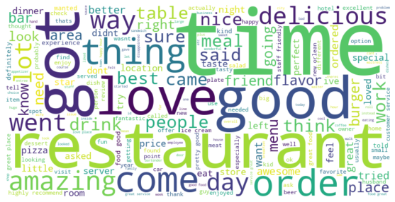

```python
# Combining all the text from the 'text' column into one string
text_data = ' '.join(df['clean_text'].tolist())

# Creating the word cloud
wordcloud = WordCloud(width=800, height=400, background_color='white').generate(text_data)

# Ploting the word cloud
plt.figure(figsize=(10, 5))
plt.imshow(wordcloud, interpolation='bilinear')
plt.axis('off')  # Turn off axis labels
plt.show()
```

### 3. Description of the analysis to be conducted

For this dataset, several NLP techniques were applied to uncover valuable insights from the reviews. One approach was sentiment analysis, which allowed us to classify reviews into positive, neutral, or negative categories based on the text. This helped correlate sentiment with star ratings and identify discrepancies, such as users leaving low-star reviews despite using generally positive language, or vice versa.

Additionally, topic modeling using Latent Dirichlet Allocation (LDA) was performed on two subsets of the data—high and low ratings. This approach identified common themes discussed in each subset, such as customer service, food quality, or delivery issues. By separating the reviews into these categories, we could compare the topics associated with high ratings versus those with low ratings, providing deeper insights into what drives customer satisfaction or dissatisfaction.

Combining sentiment analysis and topic modeling provided a comprehensive understanding of customer preferences, pain points, and the key drivers of both positive and negative experiences.

### 4. Interpretation of the results

#### 4.1. Sentiment Analysis

- Flair: The dataset utilizes a pre-trained sentiment classifier called 'sentiment-fast' to analyze the sentiment of the text. The results consist of a flair_sentiment label and a flair_score, which represents the level of confidence in the prediction.

```python
# FLAIR
tagger = Classifier.load('sentiment-fast')

i = 0
for txt in df['text']:
  try:
    text = Sentence(txt)
    tagger.predict(text)
    df.loc[i, 'flair_sentiment'] = text.tag
    df.loc[i, 'flair_score'] = text.score
  except:
    continue
  i = i+1

df
```

|  | text | stars | clean_text | flair_sentiment | flair_score |
| --- | --- | --- | --- | --- | --- |
| 0 | If you decide to eat here, just be aware it is... | 3.0 | decide eat here aware going hours beginning e... | NEGATIVE | 0.966703 |
| 1 | I've taken a lot of spin classes over the year... | 5.0 | ive taken lot spin classes years compares clas... | POSITIVE | 0.999775 |
| 2 | Family diner. Had the buffet. Eclectic assortm... | 3.0 | family diner buffet eclectic assortment large ... | POSITIVE | 0.996249 |
| 3 | Wow! Yummy, different, delicious. Our favo... | 5.0 | wow yummy different delicious favorite lamb cu... | POSITIVE | 0.999496 |
| 4 | Cute interior and owner (?) gave us tour of up... | 4.0 | cute interior owner gave tour upcoming patior... | POSITIVE | 0.998588 |
| ... | ... | ... | ... | ... | ... |
| 99995 | Came here for lunch with a group. They were bu... | 4.0 | came lunch group busy room service good portio... | POSITIVE | 0.987763 |
| 99996 | The equipment is so old and so felty! I just u... | 1.0 | equipment old felty upgraded multi club member... | NEGATIVE | 0.999512 |
| 99997 | This is one of my favorite Mexican restaurants... | 4.0 | favorite mexican restaurants authentic menu ty... | POSITIVE | 0.998412 |
| 99998 | Came here for brunch - had an omlette ($19 + t... | 2.0 | came brunch omlette tax tip food wayyyyyy... | NEGATIVE | 0.998982 |
| 99999 | Came in for my 5-6 month prophy and saw Kara -... | 5.0 | came month prophy saw kara new hygenist terr... | POSITIVE | 0.987827 |

100000 rows × 5 columns

```python
#define expected sentiment based on rating and create a new column 'expected sentiment'  in order to compare the sentiment result
def rating_to_sentiment(stars):
    if stars >= 4.0:
        return 'POSITIVE'
    elif stars <= 2.0:
        return 'NEGATIVE'
    else:
        return None  # For rating 3, we won't include it in the strict comparison

df['expected_sentiment'] = df['stars'].apply(rating_to_sentiment)

# Remove rows with rating 3 as it can be either positive or negative.
df_strict = df[df['expected_sentiment'].notnull()]

# Compare if the Flair sentiment result matches the expected sentiment from ratings
df_strict['comparison'] = df_strict['expected_sentiment'] == df_strict['flair_sentiment']
```

```python
# Calculate accuracy
accuracy = df_strict['comparison'].mean() * 100
print(f'Accuracy: {accuracy:.2f}%')

# Calculate discrepancy (mismatch rate)
discrepancy = 100 - accuracy
print(f'Discrepancy: {discrepancy:.2f}%')
# Find rows where the sentiment does not match
mismatch_df = df_strict[df_strict['comparison'] == False]

# Analyze mismatches
print(mismatch_df[['stars', 'flair_sentiment', 'expected_sentiment']])
```

```
Accuracy: 94.85%
Discrepancy: 5.15%
       stars flair_sentiment expected_sentiment
144      4.0        NEGATIVE           POSITIVE
153      5.0        NEGATIVE           POSITIVE
188      4.0        NEGATIVE           POSITIVE
201      4.0        NEGATIVE           POSITIVE
280      2.0        POSITIVE           NEGATIVE
...      ...             ...                ...
99857    5.0        NEGATIVE           POSITIVE
99918    4.0        NEGATIVE           POSITIVE
99939    4.0        NEGATIVE           POSITIVE
99966    4.0        NEGATIVE           POSITIVE
99993    4.0        NEGATIVE           POSITIVE

[4569 rows x 3 columns]
```

- VADER: This rule-based sentiment analysis tool assigns four scores for each review: positive, negative, neutral, and a compound score. These scores are stored as vader_pos, vader_neg, vader_neu, and vader_compound.

```python
# VADER
analyzer = SentimentIntensityAnalyzer()

for i in range(len(df)):
    vs = analyzer.polarity_scores(df.loc[i, 'text'])
    df.loc[i, 'vader_pos'] = vs['pos']
    df.loc[i, 'vader_neg'] = vs['neg']
    df.loc[i, 'vader_neu'] = vs['neu']
    df.loc[i, 'vader_compound'] = vs['compound']

df
```

|  | text | stars | clean_text | flair_sentiment | flair_score | expected_sentiment | vader_pos | vader_neg | vader_neu | vader_compound |
| --- | --- | --- | --- | --- | --- | --- | --- | --- | --- | --- |
| 0 | If you decide to eat here, just be aware it is... | 3.0 | decide eat here aware going hours beginning e... | NEGATIVE | 0.966703 | None | 0.107 | 0.000 | 0.893 | 0.8597 |
| 1 | I've taken a lot of spin classes over the year... | 5.0 | ive taken lot spin classes years compares clas... | POSITIVE | 0.999775 | POSITIVE | 0.238 | 0.049 | 0.713 | 0.9858 |
| 2 | Family diner. Had the buffet. Eclectic assortm... | 3.0 | family diner buffet eclectic assortment large ... | POSITIVE | 0.996249 | None | 0.245 | 0.033 | 0.722 | 0.9201 |
| 3 | Wow! Yummy, different, delicious. Our favo... | 5.0 | wow yummy different delicious favorite lamb cu... | POSITIVE | 0.999496 | POSITIVE | 0.340 | 0.000 | 0.660 | 0.9588 |
| 4 | Cute interior and owner (?) gave us tour of up... | 4.0 | cute interior owner gave tour upcoming patior... | POSITIVE | 0.998588 | POSITIVE | 0.266 | 0.016 | 0.718 | 0.9815 |
| ... | ... | ... | ... | ... | ... | ... | ... | ... | ... | ... |
| 99995 | Came here for lunch with a group. They were bu... | 4.0 | came lunch group busy room service good portio... | POSITIVE | 0.987763 | POSITIVE | 0.236 | 0.000 | 0.764 | 0.9144 |
| 99996 | The equipment is so old and so felty! I just u... | 1.0 | equipment old felty upgraded multi club member... | NEGATIVE | 0.999512 | NEGATIVE | 0.089 | 0.128 | 0.783 | -0.4356 |
| 99997 | This is one of my favorite Mexican restaurants... | 4.0 | favorite mexican restaurants authentic menu ty... | POSITIVE | 0.998412 | POSITIVE | 0.098 | 0.067 | 0.835 | 0.0772 |
| 99998 | Came here for brunch - had an omlette ($19 + t... | 2.0 | came brunch omlette tax tip food wayyyyyy... | NEGATIVE | 0.998982 | NEGATIVE | 0.116 | 0.000 | 0.884 | 0.5859 |
| 99999 | Came in for my 5-6 month prophy and saw Kara -... | 5.0 | came month prophy saw kara new hygenist terr... | POSITIVE | 0.987827 | POSITIVE | 0.262 | 0.000 | 0.738 | 0.9588 |

100000 rows × 10 columns

- Aspect-Based Sentiment Analysis (ABSA): ABSA models sentiment with respect to specific aspects of the text, such as “food” and “service” in this case. It predicts the probabilities for each aspect being positive, neutral, or negative, allowing for more granular sentiment analysis.

```python
#Aspect-Based Sentiment Analysis (ABSA)

# Load the ABSA model and tokenizer
absa_tokenizer = AutoTokenizer.from_pretrained("yangheng/deberta-v3-base-absa-v1.1")
absa_model = AutoModelForSequenceClassification.from_pretrained("yangheng/deberta-v3-base-absa-v1.1")


# Function to perform ABSA on a review with a given aspect
def absa_sentiment(review, aspect):
    inputs = absa_tokenizer(f"[CLS] {review} [SEP] {aspect} [SEP]", return_tensors="pt")
    outputs = absa_model(**inputs)
    probs = F.softmax(outputs.logits, dim=1).detach().numpy()[0]
    return dict(zip(["negative", "neutral", "positive"], probs))

# Specify the list of aspects
aspects = ["food", "service"]


# Iterate over the DataFrame and apply both ABSA and RoBERTa sentiment analysis
for i in range(1000): # due to the limitation in space and memory, I decided to run only 1000 rows of the dataset.
    review = df.loc[i, 'text']

    # ABSA Sentiment Analysis for multiple aspects
    for aspect in aspects:
        absa_scores = absa_sentiment(review, aspect)
        for key, value in absa_scores.items():
            column_name = f"{aspect}_{key}"  # Example: 'material_negative', 'price_positive', etc.
            df.loc[i, column_name] = value

# Display the updated DataFrame
df
```

|  | text | stars | clean_text | flair_sentiment | flair_score | expected_sentiment | vader_pos | vader_neg | vader_neu | vader_compound | food_negative | food_neutral | food_positive | service_negative | service_neutral | service_positive |
| --- | --- | --- | --- | --- | --- | --- | --- | --- | --- | --- | --- | --- | --- | --- | --- | --- |
| 0 | If you decide to eat here, just be aware it is... | 3.0 | decide eat here aware going hours beginning e... | NEGATIVE | 0.966703 | None | 0.107 | 0.000 | 0.893 | 0.8597 | 0.020752 | 0.007696 | 0.971552 | 0.727318 | 0.037845 | 0.234837 |
| 1 | I've taken a lot of spin classes over the year... | 5.0 | ive taken lot spin classes years compares clas... | POSITIVE | 0.999775 | POSITIVE | 0.238 | 0.049 | 0.713 | 0.9858 | 0.003934 | 0.015142 | 0.980924 | 0.003079 | 0.010135 | 0.986787 |
| 2 | Family diner. Had the buffet. Eclectic assortm... | 3.0 | family diner buffet eclectic assortment large ... | POSITIVE | 0.996249 | None | 0.245 | 0.033 | 0.722 | 0.9201 | 0.001974 | 0.023705 | 0.974321 | 0.001488 | 0.012407 | 0.986105 |
| 3 | Wow! Yummy, different, delicious. Our favo... | 5.0 | wow yummy different delicious favorite lamb cu... | POSITIVE | 0.999496 | POSITIVE | 0.340 | 0.000 | 0.660 | 0.9588 | 0.002808 | 0.023098 | 0.974094 | 0.005898 | 0.026366 | 0.967735 |
| 4 | Cute interior and owner (?) gave us tour of up... | 4.0 | cute interior owner gave tour upcoming patior... | POSITIVE | 0.998588 | POSITIVE | 0.266 | 0.016 | 0.718 | 0.9815 | 0.035566 | 0.069169 | 0.895265 | 0.027527 | 0.046046 | 0.926427 |
| ... | ... | ... | ... | ... | ... | ... | ... | ... | ... | ... | ... | ... | ... | ... | ... | ... |
| 99995 | Came here for lunch with a group. They were bu... | 4.0 | came lunch group busy room service good portio... | POSITIVE | 0.987763 | POSITIVE | 0.236 | 0.000 | 0.764 | 0.9144 | NaN | NaN | NaN | NaN | NaN | NaN |
| 99996 | The equipment is so old and so felty! I just u... | 1.0 | equipment old felty upgraded multi club member... | NEGATIVE | 0.999512 | NEGATIVE | 0.089 | 0.128 | 0.783 | -0.4356 | NaN | NaN | NaN | NaN | NaN | NaN |
| 99997 | This is one of my favorite Mexican restaurants... | 4.0 | favorite mexican restaurants authentic menu ty... | POSITIVE | 0.998412 | POSITIVE | 0.098 | 0.067 | 0.835 | 0.0772 | NaN | NaN | NaN | NaN | NaN | NaN |
| 99998 | Came here for brunch - had an omlette ($19 + t... | 2.0 | came brunch omlette tax tip food wayyyyyy... | NEGATIVE | 0.998982 | NEGATIVE | 0.116 | 0.000 | 0.884 | 0.5859 | NaN | NaN | NaN | NaN | NaN | NaN |
| 99999 | Came in for my 5-6 month prophy and saw Kara -... | 5.0 | came month prophy saw kara new hygenist terr... | POSITIVE | 0.987827 | POSITIVE | 0.262 | 0.000 | 0.738 | 0.9588 | NaN | NaN | NaN | NaN | NaN | NaN |

100000 rows × 16 columns

```python
pd.set_option('display.max_colwidth', None)

# Display the first 5 rows with full review text
print(df[['text', 'food_negative', 'food_neutral','food_positive','service_negative','service_neutral','service_positive']].head())
```

```
                                                                                                                                                                                                                                                                                                            …
0                                                                                                                                                                                                                                                                                                           …
1  I've taken a lot of spin classes over the years, and nothing compares to the classes at Body Cycle. From the nice, clean space and amazing bikes, to the welcoming and motivating instructors, every class is a top notch work out.\n\nFor anyone who struggles to fit workouts in, the online scheduling…
2                                                                                                                                                                                                                                                                                                           …
3                                                                                                                                                                                                                                                                                                           …
4                                                                                                                                                                                                                                                                                                           …

   food_negative  food_neutral  food_positive  service_negative  \
0       0.020752      0.007696       0.971552          0.727318
1       0.003934      0.015142       0.980924          0.003079
2       0.001974      0.023705       0.974321          0.001488
3       0.002808      0.023098       0.974094          0.005898
4       0.035566      0.069169       0.895265          0.027527

   service_neutral  service_positive
0         0.037845          0.234837
1         0.010135          0.986787
2         0.012407          0.986105
3         0.026366          0.967735
4         0.046046          0.926427
```

```python
pd.set_option('display.max_columns', None)
df.head()
```

|  | text | stars | clean_text | flair_sentiment | flair_score | expected_sentiment | vader_pos | vader_neg | vader_neu | vader_compound | food_negative | food_neutral | food_positive | service_negative | service_neutral | service_positive |
| --- | --- | --- | --- | --- | --- | --- | --- | --- | --- | --- | --- | --- | --- | --- | --- | --- |
| 0 | If you decide to eat here, just be aware it is going to take about 2 hours from beginning to end. We have tried it multiple times, because I want to like it! I have been to it's other locations in NJ … | 3.0 | decide eat here aware going hours beginning end tried multiple times want like it locations nj bad experience food good takes long time come waitstaff young usually pleasant experiences spent way long… | NEGATIVE | 0.966703 | None | 0.107 | 0.000 | 0.893 | 0.8597 | 0.020752 | 0.007696 | 0.971552 | 0.727318 | 0.037845 | 0.234837 |
| 1 | I've taken a lot of spin classes over the years, and nothing compares to the classes at Body Cycle. From the nice, clean space and amazing bikes, to the welcoming and motivating instructors, every cla… | 5.0 | ive taken lot spin classes years compares classes body cycle nice clean space amazing bikes welcoming motivating instructors class notch work struggles fit workouts in online scheduling system makes e… | POSITIVE | 0.999775 | POSITIVE | 0.238 | 0.049 | 0.713 | 0.9858 | 0.003934 | 0.015142 | 0.980924 | 0.003079 | 0.010135 | 0.986787 |
| 2 | Family diner. Had the buffet. Eclectic assortment: a large chicken leg, fried jalapeño, tamale, two rolled grape leaves, fresh melon. All good. Lots of Mexican choices there. Also has a menu with brea… | 3.0 | family diner buffet eclectic assortment large chicken leg fried jalapeno tamale rolled grape leaves fresh melon good lots mexican choices menu breakfast served day long friendly attentive staff good p… | POSITIVE | 0.996249 | None | 0.245 | 0.033 | 0.722 | 0.9201 | 0.001974 | 0.023705 | 0.974321 | 0.001488 | 0.012407 | 0.986105 |
| 3 | Wow! Yummy, different, delicious. Our favorite is the lamb curry and korma. With 10 different kinds of naan!!! Don't let the outside deter you (because we almost changed our minds)...go in and try som… | 5.0 | wow yummy different delicious favorite lamb curry korma different kinds naan dont let outside deter because changed minds try new youll glad did | POSITIVE | 0.999496 | POSITIVE | 0.340 | 0.000 | 0.660 | 0.9588 | 0.002808 | 0.023098 | 0.974094 | 0.005898 | 0.026366 | 0.967735 |
| 4 | Cute interior and owner (?) gave us tour of upcoming patio/rooftop area which will be great on beautiful days like today. Cheese curds were very good and very filling. Really like that sandwiches come… | 4.0 | cute interior owner gave tour upcoming patiorooftop area great beautiful days like today cheese curds good filling like sandwiches come w salad esp eating curds onion gruyere tomato sandwich wasnt che… | POSITIVE | 0.998588 | POSITIVE | 0.266 | 0.016 | 0.718 | 0.9815 | 0.035566 | 0.069169 | 0.895265 | 0.027527 | 0.046046 | 0.926427 |

I employed three sentiment analysis methods: FLAIR, VADER, Aspect-Based Sentiment Analysis (ABSA).

FLAIR: Compared to the star ratings, FLAIR performed exceptionally well, achieving an accuracy of over 94%. Since FLAIR is pre-trained on datasets that include movie and product reviews, it is highly suited for sentiment analysis in this context. Its ability to align closely with the star ratings makes it a strong method for identifying overall sentiment in the reviews.

Aspect-Based Sentiment Analysis (ABSA): ABSA allows for the evaluation of sentiments regarding specific aspects of a review, which is useful when opinions differ across attributes like food or service. I focused on two commonly mentioned aspects: 'food' and 'service' since they appear frequently in the dataset. Due to computation time and memory limitations, I analyzed only a sample of 1,000 reviews. While this was sufficient to showcase the model’s functionality, a larger sample would provide more comprehensive insights. In terms of results, after a closer evaluation of individual results, ABSA not only captured the positive and negative tones effectively and but also accurately distinguish between sentiments toward different aspects. For example, several reviews expressed positive sentiment toward the food but negative sentiment toward the service, and ABSA was able to capture this distinction effectively. This shows that the model can correctly identify aspect-specific sentiments, even though there is room for further refinement in handling more complex reviews.

All in all, the analysis provides a solid foundation for understanding how each model handles sentiment in relation to the star ratings and specific review aspects.

#### 4.2. Topic Modeling

```python
#  Create two subsets of the data using one of the metadata variables.

df1 = df[df['stars']>=3] #high ratings
df2 = df[df['stars']<3] #low ratings
df1.head()
df2.head()
```

|  | text | stars | clean_text | flair_sentiment | flair_score | expected_sentiment | vader_pos | vader_neg | vader_neu | vader_compound | food_negative | food_neutral | food_positive | service_negative | service_neutral | service_positive |
| --- | --- | --- | --- | --- | --- | --- | --- | --- | --- | --- | --- | --- | --- | --- | --- | --- |
| 5 | I am a long term frequent customer of this establishment. I just went in to order take out (3 apps) and was told they're too busy to do it. Really? The place is maybe half full at best. Does your dick… | 1.0 | long term frequent customer establishment went order apps told busy really place maybe half best dick reach ass yes fuck yourself frequent customer great tipper glad kanella opened going dmitris | NEGATIVE | 0.864956 | NEGATIVE | 0.194 | 0.123 | 0.682 | 0.7117 | 0.752343 | 0.110639 | 0.137018 | 0.892690 | 0.034667 | 0.072643 |
| 29 | I at least have to give this restaurant two stars due to the decent food. But while on a dinner meeting and after spending $100 on entrées and appetizers, I had to flag down the assistant cook, (the g… | 2.0 | restaurant stars decent food dinner meeting spending entrees appetizers flag assistant cook the guy bright red baggy pants watching tv avocado tuna entree apparent direct help situation flag waitress … | NEGATIVE | 0.990526 | NEGATIVE | 0.039 | 0.030 | 0.931 | 0.2413 | 0.017417 | 0.023776 | 0.958806 | 0.940047 | 0.039782 | 0.020171 |
| 41 | Straight to the point, it's cheap, it tastes and feels cheap\n\nThe good: price, location, dessert (edible food items are: baked chicken, fried chicken, mashed potatoes, Salad bar lol, meat and cheese… | 2.0 | straight point cheap tastes feels cheap good price location dessert edible food items are baked chicken fried chicken mashed potatoes salad bar lol meat cheese bar ravioli pizza waitress bomb af meh c… | NEGATIVE | 0.999955 | NEGATIVE | 0.076 | 0.195 | 0.729 | -0.9492 | 0.782361 | 0.128932 | 0.088708 | 0.777893 | 0.126458 | 0.095648 |
| 46 | NEVER AGAIN. This is a so called restaurant that does nothing that a restaurant should other than prepare food, because the rest is done by the patron. Want water? Get up and go across the yard to get… | 2.0 | called restaurant restaurant prepare food rest patron want water yard want drink walk flight stairs pay cash want sit dirty yard dirty lawn chairs enjoy wait staff mildy helpful bring food window pay … | NEGATIVE | 0.928227 | NEGATIVE | 0.103 | 0.081 | 0.816 | 0.1901 | 0.330247 | 0.564352 | 0.105401 | 0.623020 | 0.079600 | 0.297380 |
| 47 | If you want to pay for everything a la carte this is the place for you. \nFood wasn't terrible not impressive.\nThey brought a basket of chips and some tomato sauce which I asked politely for somethin… | 1.0 | want pay la carte place food wasnt terrible impressive brought basket chips tomato sauce asked politely spicier pico de gallo brought happily salsa better asked like drink asked coke brought bottle st… | NEGATIVE | 0.999676 | NEGATIVE | 0.087 | 0.013 | 0.900 | 0.9299 | 0.306437 | 0.343179 | 0.350384 | 0.395718 | 0.324533 | 0.279749 |

```python
#Subset 1: HIGH RATINGS

#Model 1:
# Create topic model

texts = list(df1['clean_text'])
texts = [[token.text for token in nlp(text)] for text in texts]  # Tokenize each document using SpaCy instead

dictionary = corpora.Dictionary(texts)
corpus = [dictionary.doc2bow(text) for text in texts]

lda_model_s1_1 = gensim.models.ldamodel.LdaModel(corpus = corpus, #TDM
                                           id2word = dictionary, #Dictionary
                                           num_topics = 5,
                                           random_state = 100,
                                           update_every = 1,
                                           chunksize = 100,
                                           passes = 10,
                                           alpha = 'auto',
                                           per_word_topics = True)


coherence_model_lda_s1_1 = CoherenceModel(model=lda_model_s1_1, texts=texts, dictionary=dictionary, coherence='c_v')



# Create some visualizations of the words in each topic.

# High Rating - Model 1:
for idx, topic in lda_model_s1_1.print_topics(-1):
    print('Topic: {} \nWords: {}'.format(idx, topic))
# Interactive Graphics
vis = pyLDAvis.gensim_models.prepare(lda_model_s1_1, corpus, dictionary, n_jobs = 1)

pyLDAvis.save_html(vis, 'LDA_Visualization_s1_1.html') ##saves the file
```

```
Topic: 0
Words: 0.025*"coffee" + 0.024*"breakfast" + 0.021*"sweet" + 0.017*"cream" + 0.014*"ice" + 0.013*"chocolate" + 0.012*"bacon" + 0.012*"beef" + 0.012*"seating" + 0.011*"french"
Topic: 1
Words: 0.077*" " + 0.052*"nt" + 0.019*"time" + 0.015*"like" + 0.013*"do" + 0.012*"got" + 0.010*"did" + 0.008*"know" + 0.008*"went" + 0.008*"sure"
Topic: 2
Words: 0.017*"good" + 0.016*"delicious" + 0.013*"restaurant" + 0.013*"ordered" + 0.012*"chicken" + 0.011*"ve" + 0.011*"menu" + 0.011*"fresh" + 0.010*"i" + 0.010*"food"
Topic: 3
Words: 0.050*"great" + 0.045*"place" + 0.039*"food" + 0.033*"good" + 0.027*"service" + 0.017*"love" + 0.015*"nice" + 0.015*"best" + 0.014*"amazing" + 0.013*"definitely"
Topic: 4
Words: 0.017*"staff" + 0.010*"ve" + 0.008*"recommend" + 0.007*"i" + 0.007*"clean" + 0.007*"location" + 0.007*"find" + 0.007*"work" + 0.006*"room" + 0.006*"new"
```

```python
# Model 2:
# Create topic model

dictionary.filter_extremes(no_below=10, no_above=0.9)
corpus2 = [dictionary.doc2bow(text) for text in texts]

lda_model_s1_2 = gensim.models.ldamodel.LdaModel(corpus = corpus2, #TDM
                                           id2word = dictionary, #Dictionary
                                           num_topics = 5,
                                           random_state = 100,
                                           update_every = 1,
                                           chunksize = 100,
                                           passes = 20, #Let the model train longer
                                           alpha = 'auto',
                                           per_word_topics = True)

coherence_model_lda_s1_2 = CoherenceModel(model=lda_model_s1_2, texts=texts, dictionary=dictionary, coherence='c_v')


# High Rating - Model 2:
for idx, topic in lda_model_s1_2.print_topics(-1):
    print('Topic: {} \nWords: {}'.format(idx, topic))

vis = pyLDAvis.gensim_models.prepare(lda_model_s1_2, corpus2, dictionary, n_jobs = 1)

pyLDAvis.save_html(vis, 'LDA_Visualization_s1_2.html') ##saves the file
```

```
Topic: 0
Words: 0.032*" " + 0.017*"experience" + 0.015*"time" + 0.014*"went" + 0.013*"day" + 0.012*"got" + 0.011*"took" + 0.011*"came" + 0.010*"wine" + 0.009*"wanted"
Topic: 1
Words: 0.056*"nt" + 0.025*"i" + 0.021*"ve" + 0.016*"like" + 0.014*"do" + 0.010*"s" + 0.009*"did" + 0.009*"know" + 0.009*"going" + 0.008*"time"
Topic: 2
Words: 0.062*" " + 0.040*"good" + 0.026*"place" + 0.021*"food" + 0.013*"little" + 0.010*"pretty" + 0.010*"bar" + 0.010*"like" + 0.009*"pizza" + 0.008*"night"
Topic: 3
Words: 0.071*"great" + 0.036*"service" + 0.025*"place" + 0.022*"friendly" + 0.022*"staff" + 0.022*"love" + 0.021*"food" + 0.017*"best" + 0.016*"amazing" + 0.016*"nice"
Topic: 4
Words: 0.019*"delicious" + 0.014*"food" + 0.013*"ordered" + 0.012*"chicken" + 0.012*"restaurant" + 0.012*"fresh" + 0.010*"menu" + 0.010*"cheese" + 0.009*"lunch" + 0.009*"sauce"
```

```python
# HIGH RATINGS
print('\nCoherence Score for High Rating - First Model: ', coherence_model_lda_s1_1.get_coherence())
print('\nPerplexity for  High Rating - First Model: ', lda_model_s1_1.log_perplexity(corpus))
print('\nCoherence Score for  High Rating  Second Model: ', coherence_model_lda_s1_2.get_coherence())
print('\nPerplexity for  High Rating  Second Model: ', lda_model_s1_2.log_perplexity(corpus2))
```

```
Coherence Score for High Rating - First Model:  0.30138466360322813

Perplexity for  High Rating - First Model:  -8.07499689981059

Coherence Score for  High Rating  Second Model:  0.42453347132490044

Perplexity for  High Rating  Second Model:  -7.64430715583812
```

```python
#Subset 2: LOW RATINGS

#Model 1:
# Create topic model

texts = list(df2['clean_text'])
# texts = [nltk.word_tokenize(text) for text in texts]  #ERROR
texts = [[token.text for token in nlp(text)] for text in texts]  # Tokenize each document using SpaCy instead

dictionary = corpora.Dictionary(texts)
corpus = [dictionary.doc2bow(text) for text in texts]

lda_model_s2_1 = gensim.models.ldamodel.LdaModel(corpus = corpus, #TDM
                                           id2word = dictionary, #Dictionary
                                           num_topics = 5,
                                           random_state = 100,
                                           update_every = 1,
                                           chunksize = 100,
                                           passes = 10,
                                           alpha = 'auto',
                                           per_word_topics = True)


coherence_model_lda_s2_1 = CoherenceModel(model=lda_model_s2_1, texts=texts, dictionary=dictionary, coherence='c_v')


# Low Rating - Model 1:

for idx, topic in lda_model_s2_1.print_topics(-1):
    print('Topic: {} \nWords: {}'.format(idx, topic))
# Interactive Graphics
vis = pyLDAvis.gensim_models.prepare(lda_model_s2_1, corpus, dictionary, n_jobs = 1)

pyLDAvis.save_html(vis, 'LDA_Visualization_s2_1.html') ##saves the file
```

```
Topic: 0
Words: 0.024*"ordered" + 0.023*"chicken" + 0.017*"sandwich" + 0.016*"sauce" + 0.015*"cheese" + 0.015*"like" + 0.014*"good" + 0.013*"salad" + 0.012*"food" + 0.011*"tasted"
Topic: 1
Words: 0.024*"place" + 0.021*"good" + 0.014*"better" + 0.012*"great" + 0.011*"nice" + 0.008*"like" + 0.008*"food" + 0.008*"pretty" + 0.007*"price" + 0.007*"quality"
Topic: 2
Words: 0.057*" " + 0.047*"food" + 0.027*"order" + 0.020*"minutes" + 0.019*"came" + 0.018*"service" + 0.014*"restaurant" + 0.014*"table" + 0.013*"ordered" + 0.011*"wait"
Topic: 3
Words: 0.025*"room" + 0.018*" " + 0.017*"called" + 0.015*"told" + 0.014*"car" + 0.011*"hotel" + 0.011*"phone" + 0.009*"shop" + 0.009*"card" + 0.009*"month"
Topic: 4
Words: 0.046*"nt" + 0.037*" " + 0.012*"do" + 0.011*"time" + 0.010*"did" + 0.009*"like" + 0.009*"place" + 0.008*"i" + 0.008*"service" + 0.007*"know"
```

```python
# Model 2:

# Create topic model

dictionary.filter_extremes(no_below=10, no_above=0.9)
corpus2 = [dictionary.doc2bow(text) for text in texts]

lda_model_s2_2 = gensim.models.ldamodel.LdaModel(corpus = corpus2, #TDM
                                           id2word = dictionary, #Dictionary
                                           num_topics = 5,
                                           random_state = 100,
                                           update_every = 1,
                                           chunksize = 100,
                                           passes = 20, #Let the model train longer
                                           alpha = 'auto',
                                           per_word_topics = True)

coherence_model_lda_s2_2 = CoherenceModel(model=lda_model_s2_2, texts=texts, dictionary=dictionary, coherence='c_v')


# Low Rating - Model 2:

for idx, topic in lda_model_s2_2.print_topics(-1):
    print('Topic: {} \nWords: {}'.format(idx, topic))

vis = pyLDAvis.gensim_models.prepare(lda_model_s2_2, corpus2, dictionary, n_jobs = 1)

pyLDAvis.save_html(vis, 'LDA_Visualization_s2_2.html') ##saves the file
```

```
Topic: 0
Words: 0.039*"chicken" + 0.027*"sauce" + 0.019*"tasted" + 0.015*"flavor" + 0.015*"dry" + 0.014*"like" + 0.014*"rice" + 0.013*"fried" + 0.013*"meat" + 0.012*"ordered"
Topic: 1
Words: 0.036*"food" + 0.029*"good" + 0.018*"ordered" + 0.016*"place" + 0.012*"like" + 0.011*"better" + 0.010*"pizza" + 0.010*"menu" + 0.008*"restaurant" + 0.008*"sandwich"
Topic: 2
Words: 0.023*" " + 0.015*"told" + 0.013*"customer" + 0.012*"called" + 0.012*"said" + 0.009*"store" + 0.009*"shop" + 0.009*"business" + 0.008*"car" + 0.008*"day"
Topic: 3
Words: 0.032*"room" + 0.018*"old" + 0.013*"hotel" + 0.013*"stay" + 0.012*"floor" + 0.010*"park" + 0.009*"door" + 0.009*"clean" + 0.009*"street" + 0.008*"desk"
Topic: 4
Words: 0.058*" " + 0.046*"nt" + 0.017*"service" + 0.013*"time" + 0.012*"order" + 0.012*"do" + 0.012*"did" + 0.011*"place" + 0.009*"food" + 0.009*"minutes"
```

```python
# LOW RATINGS
print('\nCoherence Score for  Low Rating - First Model: ', coherence_model_lda_s2_1.get_coherence())
print('\nPerplexity for  Low Rating - First Model: ', lda_model_s2_1.log_perplexity(corpus))
print('\nCoherence Score for  Low Rating - Second Model: ', coherence_model_lda_s2_2.get_coherence())
print('\nPerplexity for  Low Rating - Second Model: ', lda_model_s2_2.log_perplexity(corpus2))
```

```
Coherence Score for  Low Rating - First Model:  0.38770418840750676

Perplexity for  Low Rating - First Model:  -7.997025095857831

Coherence Score for  Low Rating - Second Model:  0.48102359110386556

Perplexity for  Low Rating - Second Model:  -7.383320291253396
```

We ran two separate subsets, one for high ratings and one for low ratings, to explore and compare the topics that emerge from each subset. And for each subset, we ran 2 LDA models. The second model is an updated version of the first one, with limited dictionary and higher number of passes.

**Coherence and Perplexity Scores:**

- High Ratings:

Model 1: Coherence Score: 0.30; Perplexity Score: -8.07.

Model 2: Coherence Score: 0.42; Perplexity Score: -7.6.

By increasing number of passes and limiting the dictionary by filtering out words appearing in fewer than 10 documents and more than 90% document (the extreme values) in Model 2, the coherence score increases and perplexity score shows lower magnitude indicating that it provides more interpretable topics and has stronger predictive performance than Model 1 and thus it is a better choice in terms of both coherence and perplexity.

- Low Ratings:

Model 1: Coherence Score: 0.39; Perplexity Score: -7.99.

Model 2: Coherence Score: 0.48; Perplexity Score: -7.38. The model 2 in low ratings subset also show better result in terms of both coherence and perplexity.

### 5. Discussion of the insights and/or recommendations for application of the model or results

#### Insights from Models

Both sentiment analysis and topic modeling provide valuable insights into customer reviews and their associated themes. Sentiment analysis, particularly using models like FLAIR and VADER, offers an overview of how customers feel about various aspects of the restaurants they review. This sentiment can be further enriched by the topic modeling results from LDA, which help identify key themes from both high and low-rated reviews.

1. **Sentiment and Topic Modeling**

Using FLAIR and VADER models, we performed sentiment analysis across Yelp reviews to extract general customer sentiments. The model output helped identify patterns of positive, negative, and neutral feedback.

Topic modeling using LDA revealed key themes in the reviews, such as food quality, service experience, and ambiance. This allowed us to categorize common points of customer praise and complaints.

2. **Aspect-Based Sentiment Analysis (ABSA)**

By performing ABSA, we identified specific sentiments related to different aspects like food and service. This detailed breakdown is particularly useful for restaurants to focus on the areas that matter most to customers. For example, a restaurant may have generally positive reviews but score poorly on service aspects, which could highlight a critical improvement area.

#### Recommendations

1. **Targeted Service and Food Quality Improvements**

Based on the topics generated from low-rated reviews, restaurants should focus on improving the aspects of service and food that are frequently mentioned negatively. This targeted action will likely lead to a tangible increase in customer satisfaction and overall ratings.

2. **Marketing and Promotion Optimization**

High-rated reviews offer insights into aspects that customers appreciate the most, such as ambiance or food variety. Restaurants can capitalize on these positive attributes in their marketing efforts, potentially highlighting these strengths to attract new customers or drive loyalty of existing customers.

3. **Drive Operational Efficiency**

Insights from reviews where operational inefficiencies are mentioned, such as long wait times, and poor customer service, can inform operational strategies to improve efficiency. Training staff, improving kitchen workflows, or streamlining service processes could directly reduce negative feedback.

4. **Create Precautionary Alerts**

Restaurants can implement an alert system based on early signals from negative reviews or drops in star ratings, enabling proactive measures before issues escalate. This system could serve as a real-time feedback loop for restaurant managers, allowing them to respond to complaints before they become systemic problems.